# Что определяет успех видеоигр?

## Описание проекта

**Цель** - на основе исторических данных выявить закономерности, определяющие успешность видеоигры.

**Задачи проекта:**

- определить актуальный период анализа;
- выявить потенциально прибыльные платформы и жанры игр;
- проверить зависимость продаж от оценок критиков и игроков;
- проверить зависимость рейтинга игроков от жанра и платформы игры;
- дать характеристику целевой аудитории трёх разных регионов: определить предпочтения в жанрах и платформах, а также возраст игроков;
- дать отделу маркетинга рекомендации по рекламе онлайн-магазина игр.

## Подготовка данных

### Выгрузка данных

```python
#импорт библиотек для работы с данными
import pandas as pd
import numpy as np
import seaborn as sns
from scipy import stats as st
from matplotlib import pyplot as plt
```

```python
#фильтрация предупреждений
import warnings

warnings.filterwarnings("ignore")
```

```python
#получение данных об играх
try:
   games = pd.read_csv('/datasets/games.csv')
except:
   games = pd.read_csv('games.csv')
```

### Настройка формата данных

```python
#настройка полноты вывода данных (вывод максимального кол-ва столбцов)
pd.set_option('display.max_columns', None)
```

```python
#настройка формата чисел (дробные числа отображаются с 2-мя знаками после запятой)
pd.set_option('display.float_format', '{:.2f}'.format)
```

### Обзор данных

```python
#вывод первых 5-ти строк датасета
games.head(5)
```

|  | Name | Platform | Year_of_Release | Genre | NA_sales | EU_sales | JP_sales | Other_sales | Critic_Score | User_Score | Rating |
| --- | --- | --- | --- | --- | --- | --- | --- | --- | --- | --- | --- |
| 0 | Wii Sports | Wii | 2006.00 | Sports | 41.36 | 28.96 | 3.77 | 8.45 | 76.00 | 8 | E |
| 1 | Super Mario Bros. | NES | 1985.00 | Platform | 29.08 | 3.58 | 6.81 | 0.77 | NaN | NaN | NaN |
| 2 | Mario Kart Wii | Wii | 2008.00 | Racing | 15.68 | 12.76 | 3.79 | 3.29 | 82.00 | 8.3 | E |
| 3 | Wii Sports Resort | Wii | 2009.00 | Sports | 15.61 | 10.93 | 3.28 | 2.95 | 80.00 | 8 | E |
| 4 | Pokemon Red/Pokemon Blue | GB | 1996.00 | Role-Playing | 11.27 | 8.89 | 10.22 | 1.00 | NaN | NaN | NaN |

```python
#вывод последних 5-ти строк датасета
games.tail(5)
```

|  | Name | Platform | Year_of_Release | Genre | NA_sales | EU_sales | JP_sales | Other_sales | Critic_Score | User_Score | Rating |
| --- | --- | --- | --- | --- | --- | --- | --- | --- | --- | --- | --- |
| 16710 | Samurai Warriors: Sanada Maru | PS3 | 2016.00 | Action | 0.00 | 0.00 | 0.01 | 0.00 | NaN | NaN | NaN |
| 16711 | LMA Manager 2007 | X360 | 2006.00 | Sports | 0.00 | 0.01 | 0.00 | 0.00 | NaN | NaN | NaN |
| 16712 | Haitaka no Psychedelica | PSV | 2016.00 | Adventure | 0.00 | 0.00 | 0.01 | 0.00 | NaN | NaN | NaN |
| 16713 | Spirits & Spells | GBA | 2003.00 | Platform | 0.01 | 0.00 | 0.00 | 0.00 | NaN | NaN | NaN |
| 16714 | Winning Post 8 2016 | PSV | 2016.00 | Simulation | 0.00 | 0.00 | 0.01 | 0.00 | NaN | NaN | NaN |

Необходимо привести названия колонок к нижнему регистру, как принято в стиле snake_case.

```python
#вывод информации по датасету
games.info()
```

```
<class 'pandas.core.frame.DataFrame'>
RangeIndex: 16715 entries, 0 to 16714
Data columns (total 11 columns):
 #   Column           Non-Null Count  Dtype
---  ------           --------------  -----
 0   Name             16713 non-null  object
 1   Platform         16715 non-null  object
 2   Year_of_Release  16446 non-null  float64
 3   Genre            16713 non-null  object
 4   NA_sales         16715 non-null  float64
 5   EU_sales         16715 non-null  float64
 6   JP_sales         16715 non-null  float64
 7   Other_sales      16715 non-null  float64
 8   Critic_Score     8137 non-null   float64
 9   User_Score       10014 non-null  object
 10  Rating           9949 non-null   object
dtypes: float64(6), object(5)
memory usage: 1.4+ MB
```

### Проверка данных на пропуски

```python
#функция для подсчёта пропусков и их доли от общего кол-ва значений
def nan_values(df):
    count_missing = df.isna().sum()
    percent_missing = round(df.isna().sum() * 100 / len(df), 2)

    missing_value_df = pd.DataFrame({'num_missing': count_missing,
                                     'percent_missing': percent_missing})

    return missing_value_df
```

```python
#подсчёт пропусков и их доли от общего кол-ва значений
display(nan_values(games).sort_values(by = 'percent_missing', ascending = False))
```

|  | num_missing | percent_missing |
| --- | --- | --- |
| Critic_Score | 8578 | 51.32 |
| Rating | 6766 | 40.48 |
| User_Score | 6701 | 40.09 |
| Year_of_Release | 269 | 1.61 |
| Name | 2 | 0.01 |
| Genre | 2 | 0.01 |
| Platform | 0 | 0.00 |
| NA_sales | 0 | 0.00 |
| EU_sales | 0 | 0.00 |
| JP_sales | 0 | 0.00 |
| Other_sales | 0 | 0.00 |

```python
#проверка двух записей, где отсутствуют имя и жанр
games.loc[games['Genre'].isna()]
```

|  | Name | Platform | Year_of_Release | Genre | NA_sales | EU_sales | JP_sales | Other_sales | Critic_Score | User_Score | Rating |
| --- | --- | --- | --- | --- | --- | --- | --- | --- | --- | --- | --- |
| 659 | NaN | GEN | 1993.00 | NaN | 1.78 | 0.53 | 0.00 | 0.08 | NaN | NaN | NaN |
| 14244 | NaN | GEN | 1993.00 | NaN | 0.00 | 0.00 | 0.03 | 0.00 | NaN | NaN | NaN |

```python
#проверка записей, где отсутствует год
games.loc[games['Year_of_Release'].isna()].head(5)
```

|  | Name | Platform | Year_of_Release | Genre | NA_sales | EU_sales | JP_sales | Other_sales | Critic_Score | User_Score | Rating |
| --- | --- | --- | --- | --- | --- | --- | --- | --- | --- | --- | --- |
| 183 | Madden NFL 2004 | PS2 | NaN | Sports | 4.26 | 0.26 | 0.01 | 0.71 | 94.00 | 8.5 | E |
| 377 | FIFA Soccer 2004 | PS2 | NaN | Sports | 0.59 | 2.36 | 0.04 | 0.51 | 84.00 | 6.4 | E |
| 456 | LEGO Batman: The Videogame | Wii | NaN | Action | 1.80 | 0.97 | 0.00 | 0.29 | 74.00 | 7.9 | E10+ |
| 475 | wwe Smackdown vs. Raw 2006 | PS2 | NaN | Fighting | 1.57 | 1.02 | 0.00 | 0.41 | NaN | NaN | NaN |
| 609 | Space Invaders | 2600 | NaN | Shooter | 2.36 | 0.14 | 0.00 | 0.03 | NaN | NaN | NaN |

```python
#проверка записей, где отсутствует год
games.loc[games['Year_of_Release'].isna()].tail(5)
```

|  | Name | Platform | Year_of_Release | Genre | NA_sales | EU_sales | JP_sales | Other_sales | Critic_Score | User_Score | Rating |
| --- | --- | --- | --- | --- | --- | --- | --- | --- | --- | --- | --- |
| 16373 | PDC World Championship Darts 2008 | PSP | NaN | Sports | 0.01 | 0.00 | 0.00 | 0.00 | 43.00 | tbd | E10+ |
| 16405 | Freaky Flyers | GC | NaN | Racing | 0.01 | 0.00 | 0.00 | 0.00 | 69.00 | 6.5 | T |
| 16448 | Inversion | PC | NaN | Shooter | 0.01 | 0.00 | 0.00 | 0.00 | 59.00 | 6.7 | M |
| 16458 | Hakuouki: Shinsengumi Kitan | PS3 | NaN | Adventure | 0.01 | 0.00 | 0.00 | 0.00 | NaN | NaN | NaN |
| 16522 | Virtua Quest | GC | NaN | Role-Playing | 0.01 | 0.00 | 0.00 | 0.00 | 55.00 | 5.5 | T |

**Наблюдения по пропускам:**

- на **половину** игр нет рецензий игровых критиков;
- **40%** игр не получили оценку от пользователей;
- для **1.6%** игр не указана дата релиза;
- для **двух** игр не указано имя и жанр.

**Возможные причины отсутвия оценки игр со стороны критиков и игроков:**

- до начала 1999-го года не было сайтов, которые собирали бы оценки на видеоигры: первым таким сайтом-агрегатором стал GameRanking (1999-2019), затем в 2001 году появился самый популярный в индустрии игр сайт-агрегатор — Metacritic (судя 100-бальной системе, данные взяты именно с этого сайта-агрегатора);
- игры создавались для локальной аудитории и не получили широкой огласки: например, в таблице есть игры, продажи которых состоялись в конкретном регионе и не превысили 10 000 копий;
- игру ещё не успели оценить, так как она ещё не поступила в продажу и разработчики не высылали игру на рецензию игровым критикам.

**Возможные причины отсутствия рейтинга со стороны ESRB:**

- ESRB начала функционировать только с 1994-го года, и игры, которые были выпущены до этого года, могли не получить рейтинг ESRB;
- игры не распространялись или не были произведены на территории США (согласно [сайту ESRB](https://www.esrb.org/faqs/#are-all-games-required-to-have-a-rating), рейтинг ESRB является обязательным только для ритейлеров и компаний по производству игр в США).

**Возможные причины отсутствия года:**

- даты отсутствуют как для игр середины 2000-х, так и для игр 2010-х — возможно, что данные потерялись по каким-то техническим причинам.

### Проверка данных на аномалии и дубликаты

```python
#функция для проверки данных на наличие аномальных значений
def describe_cols(df):

    values = pd.DataFrame()

    for col in df.columns:
        values[col] = [df[col].unique(), df[col].nunique()]

    return values.transpose().sort_values(by=1, ascending=True).rename(
        {0: 'Значения', 1: 'Кол-во уникальных значений'}, axis=1)
```

```python
#поверка данных на наличие аномальных значений
display(describe_cols(games))
```

|  | Значения | Кол-во уникальных значений |
| --- | --- | --- |
| Rating | [E, nan, M, T, E10+, K-A, AO, EC, RP] | 8 |
| Genre | [Sports, Platform, Racing, Role-Playing, Puzzl... | 12 |
| Platform | [Wii, NES, GB, DS, X360, PS3, PS2, SNES, GBA, ... | 31 |
| Year_of_Release | [2006.0, 1985.0, 2008.0, 2009.0, 1996.0, 1989.... | 37 |
| Critic_Score | [76.0, nan, 82.0, 80.0, 89.0, 58.0, 87.0, 91.0... | 82 |
| User_Score | [8, nan, 8.3, 8.5, 6.6, 8.4, 8.6, 7.7, 6.3, 7.... | 96 |
| Other_sales | [8.45, 0.77, 3.29, 2.95, 1.0, 0.58, 2.88, 2.84... | 155 |
| JP_sales | [3.77, 6.81, 3.79, 3.28, 10.22, 4.22, 6.5, 2.9... | 244 |
| EU_sales | [28.96, 3.58, 12.76, 10.93, 8.89, 2.26, 9.14, ... | 307 |
| NA_sales | [41.36, 29.08, 15.68, 15.61, 11.27, 23.2, 11.2... | 402 |
| Name | [Wii Sports, Super Mario Bros., Mario Kart Wii... | 11559 |

В колонке `Rating` выявлены неявные дубликаты: согласно [Wikipedia](https://ru.wikipedia.org/wiki/Entertainment_Software_Rating_Board), до 1999 рейтинг «Для всех» обозначался как «K-A», после 1999 он стал обозначаться как «E». В таблице присутствуют оба варианта.

```python
#проверка на дубликаты записей игр
games.sort_values(by='Name').head(5)
```

|  | Name | Platform | Year_of_Release | Genre | NA_sales | EU_sales | JP_sales | Other_sales | Critic_Score | User_Score | Rating |
| --- | --- | --- | --- | --- | --- | --- | --- | --- | --- | --- | --- |
| 14983 | Beyblade Burst | 3DS | 2016.00 | Role-Playing | 0.00 | 0.00 | 0.03 | 0.00 | NaN | NaN | NaN |
| 1079 | Fire Emblem Fates | 3DS | 2015.00 | Role-Playing | 0.81 | 0.23 | 0.52 | 0.11 | NaN | NaN | NaN |
| 3358 | Frozen: Olaf's Quest | 3DS | 2013.00 | Platform | 0.27 | 0.27 | 0.00 | 0.05 | NaN | NaN | NaN |
| 3862 | Frozen: Olaf's Quest | DS | 2013.00 | Platform | 0.21 | 0.26 | 0.00 | 0.04 | NaN | NaN | NaN |
| 13794 | Haikyu!! Cross Team Match! | 3DS | 2016.00 | Adventure | 0.00 | 0.00 | 0.04 | 0.00 | NaN | NaN | NaN |

Из таблицы видно, что одна и та же игра может выходить на разных платформах: например, игра Frozen: Olaf's Quest вышла одновременно на Nintendo DS и Nintendo 3DS.

```python
#поверка на наличие полных дубликат
games[['Name','Platform']].duplicated().sum()
```

```
5
```

```python
#просмотр строк с дубликатами
games[games[['Name','Platform']].duplicated()]
```

|  | Name | Platform | Year_of_Release | Genre | NA_sales | EU_sales | JP_sales | Other_sales | Critic_Score | User_Score | Rating |
| --- | --- | --- | --- | --- | --- | --- | --- | --- | --- | --- | --- |
| 1591 | Need for Speed: Most Wanted | X360 | 2005.00 | Racing | 1.00 | 0.13 | 0.02 | 0.10 | 83.00 | 8.5 | T |
| 4127 | Sonic the Hedgehog | PS3 | NaN | Platform | 0.00 | 0.48 | 0.00 | 0.00 | 43.00 | 4.1 | E10+ |
| 11715 | Need for Speed: Most Wanted | PC | 2012.00 | Racing | 0.00 | 0.06 | 0.00 | 0.02 | 82.00 | 8.5 | T |
| 14244 | NaN | GEN | 1993.00 | NaN | 0.00 | 0.00 | 0.03 | 0.00 | NaN | NaN | NaN |
| 16230 | Madden NFL 13 | PS3 | 2012.00 | Sports | 0.00 | 0.01 | 0.00 | 0.00 | 83.00 | 5.5 | E |

```python
#вывод дублированных строк
games[games[['Name','Platform']].duplicated(keep=False)]
```

|  | Name | Platform | Year_of_Release | Genre | NA_sales | EU_sales | JP_sales | Other_sales | Critic_Score | User_Score | Rating |
| --- | --- | --- | --- | --- | --- | --- | --- | --- | --- | --- | --- |
| 604 | Madden NFL 13 | PS3 | 2012.00 | Sports | 2.11 | 0.22 | 0.00 | 0.23 | 83.00 | 5.5 | E |
| 659 | NaN | GEN | 1993.00 | NaN | 1.78 | 0.53 | 0.00 | 0.08 | NaN | NaN | NaN |
| 1190 | Need for Speed: Most Wanted | X360 | 2012.00 | Racing | 0.62 | 0.78 | 0.01 | 0.15 | 83.00 | 8.5 | T |
| 1591 | Need for Speed: Most Wanted | X360 | 2005.00 | Racing | 1.00 | 0.13 | 0.02 | 0.10 | 83.00 | 8.5 | T |
| 1745 | Sonic the Hedgehog | PS3 | 2006.00 | Platform | 0.41 | 0.06 | 0.04 | 0.66 | 43.00 | 4.1 | E10+ |
| 4127 | Sonic the Hedgehog | PS3 | NaN | Platform | 0.00 | 0.48 | 0.00 | 0.00 | 43.00 | 4.1 | E10+ |
| 5972 | Need for Speed: Most Wanted | PC | 2005.00 | Racing | 0.02 | 0.23 | 0.00 | 0.04 | 82.00 | 8.5 | T |
| 11715 | Need for Speed: Most Wanted | PC | 2012.00 | Racing | 0.00 | 0.06 | 0.00 | 0.02 | 82.00 | 8.5 | T |
| 14244 | NaN | GEN | 1993.00 | NaN | 0.00 | 0.00 | 0.03 | 0.00 | NaN | NaN | NaN |
| 16230 | Madden NFL 13 | PS3 | 2012.00 | Sports | 0.00 | 0.01 | 0.00 | 0.00 | 83.00 | 5.5 | E |

```python
#вывод списка всех жанров — проверка на неявные дубликаты
games['Genre'].unique()
```

```
array(['Sports', 'Platform', 'Racing', 'Role-Playing', 'Puzzle', 'Misc',
       'Shooter', 'Simulation', 'Action', 'Fighting', 'Adventure',
       'Strategy', nan], dtype=object)
```

Неявных дубликатов среди имён жанров не обнаружено.

```python
#вывод всех уникальных оценок пользователей
games['User_Score'].unique()
```

```
array(['8', nan, '8.3', '8.5', '6.6', '8.4', '8.6', '7.7', '6.3', '7.4',
       '8.2', '9', '7.9', '8.1', '8.7', '7.1', '3.4', '5.3', '4.8', '3.2',
       '8.9', '6.4', '7.8', '7.5', '2.6', '7.2', '9.2', '7', '7.3', '4.3',
       '7.6', '5.7', '5', '9.1', '6.5', 'tbd', '8.8', '6.9', '9.4', '6.8',
       '6.1', '6.7', '5.4', '4', '4.9', '4.5', '9.3', '6.2', '4.2', '6',
       '3.7', '4.1', '5.8', '5.6', '5.5', '4.4', '4.6', '5.9', '3.9',
       '3.1', '2.9', '5.2', '3.3', '4.7', '5.1', '3.5', '2.5', '1.9', '3',
       '2.7', '2.2', '2', '9.5', '2.1', '3.6', '2.8', '1.8', '3.8', '0',
       '1.6', '9.6', '2.4', '1.7', '1.1', '0.3', '1.5', '0.7', '1.2',
       '2.3', '0.5', '1.3', '0.2', '0.6', '1.4', '0.9', '1', '9.7'],
      dtype=object)
```

В списке оценок обнаружено странное значение — «tbd». Согласно [Urban Dictionary](https://www.urbandictionary.com/define.php?term=TBD), «tbd» расшифровывается как «to be decided» и значит, что оценка за игру ещё не выставлена, т.к. игроки ещё не решили, что поставить игре.

```python
#вывод всех уникальных оценок критиков
games['Critic_Score'].unique()
```

```
array([76., nan, 82., 80., 89., 58., 87., 91., 61., 97., 95., 77., 88.,
       83., 94., 93., 85., 86., 98., 96., 90., 84., 73., 74., 78., 92.,
       71., 72., 68., 62., 49., 67., 81., 66., 56., 79., 70., 59., 64.,
       75., 60., 63., 69., 50., 25., 42., 44., 55., 48., 57., 29., 47.,
       65., 54., 20., 53., 37., 38., 33., 52., 30., 32., 43., 45., 51.,
       40., 46., 39., 34., 35., 41., 36., 28., 31., 27., 26., 19., 23.,
       24., 21., 17., 22., 13.])
```

Неявных дубликатов или странных значений не обнаружено.

### План по предобработке данных

**Прежде чем приступать к исследовательскому анализу, необходимо:**

1. Переименовать все колонки в соответствии со стилем snake_case.
2. Поменять в столбце `Year_of_Release` тип данных на тип datetime.
3. Пропуски со значением NaN в столбцах `Critic_Score`, `User_Score`заменить на 0.
4. Удалить строки 16230 (Madden NFL 13, PS3, NA_sales = 0) и 4127 (Sonic the Hedgehog, PS3, NA_sales = 0).
5. Удалить строки с играми, у которых не указаны имя и жанр.
6. Поменять в столбце `Critic_Score` тип данных на тип int.
7. Заменить «K-A» на «E» в колонке `Rating`.
8. Заменить NaN на unknown в колонке `Rating`.
9. Заменить «tbd» в колонке `User_Score` на -1.
10. Поменять в столбце `User_Score` тип данных на тип float.

## Предобработка данных

### Изменение имён колонок

```python
#смена регистра имён колонок
games.columns = games.columns.str.lower()
games.columns
```

```
Index(['name', 'platform', 'year_of_release', 'genre', 'na_sales', 'eu_sales',
       'jp_sales', 'other_sales', 'critic_score', 'user_score', 'rating'],
      dtype='object')
```

### Замена типа данных и пропусков, удаление дубликатов

```python
#замена типа данных в колонке `year_of_release` на тип datetime
games['year_of_release'] = pd.to_datetime(games['year_of_release'], format='%Y', errors='coerce')
games['year_of_release'] = games['year_of_release'].dt.year
games.head(5)
```

|  | name | platform | year_of_release | genre | na_sales | eu_sales | jp_sales | other_sales | critic_score | user_score | rating |
| --- | --- | --- | --- | --- | --- | --- | --- | --- | --- | --- | --- |
| 0 | Wii Sports | Wii | 2006.00 | Sports | 41.36 | 28.96 | 3.77 | 8.45 | 76.00 | 8 | E |
| 1 | Super Mario Bros. | NES | 1985.00 | Platform | 29.08 | 3.58 | 6.81 | 0.77 | NaN | NaN | NaN |
| 2 | Mario Kart Wii | Wii | 2008.00 | Racing | 15.68 | 12.76 | 3.79 | 3.29 | 82.00 | 8.3 | E |
| 3 | Wii Sports Resort | Wii | 2009.00 | Sports | 15.61 | 10.93 | 3.28 | 2.95 | 80.00 | 8 | E |
| 4 | Pokemon Red/Pokemon Blue | GB | 1996.00 | Role-Playing | 11.27 | 8.89 | 10.22 | 1.00 | NaN | NaN | NaN |

```python
#замена NaN на 0 в столбцах `critic_score`, `user_score`
games['critic_score'] = games['critic_score'].fillna(0)
games['user_score'] = games['user_score'].fillna(0)
```

```python
#удаление двух строк, дублирующих данные по Madden NFL 13 и Sonic the Hedgehog
games = games.drop(index = [16230, 4127]).reset_index(drop=True)
```

```python
#удаление двух строк, где не указаны жанр и имя игры
games = games.dropna(subset=['name', 'genre']).reset_index(drop=True)
```

```python
#замена типа данных в колонке `critic_score' на int
games['critic_score'] = games['critic_score'].astype(int)
```

```python
#замена значения "K-A" на "E"
games['rating'] = games['rating'].replace('K-A', 'E')
```

```python
#замена пропусков на значение unknown
games['rating'] = games['rating'].fillna("unknown")
```

```python
#замена значения "tbd" на 0
games['user_score'] = games['user_score'].replace('tbd', -1)
```

```python
#замена типа данных в колонке `user_score' на int
games['user_score'] = games['user_score'].astype(float)
```

### Добавление новых данных

```python
#создание столбца с суммарными продажами во всех регионах по каждой игре
games['sales_sum'] = games['na_sales'] + games['eu_sales'] + games['jp_sales'] + games['other_sales']
```

## Исследовательский анализ данных

### Выбор актуального периода анализа

#### Изучение общего объёма продаж по годам

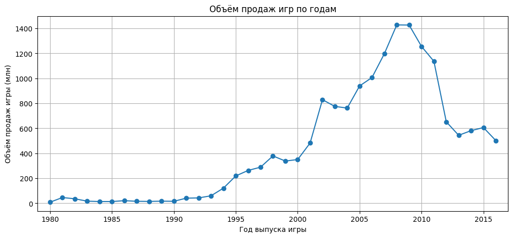

```python
#построение линейного графика выпуска игр
games.groupby('year_of_release')['name'].count().plot(grid=True, xlim = (1979, 2017),
                                                          figsize = (12,5), style='o-')
plt.title('Объём продаж игр по годам')
plt.xlabel('Год выпуска игры')
plt.ylabel('Объём продаж игры (млн)')
plt.show()
```

**Описание графика:**

(1) С начала 1980-х до середины 1990-х производство игр находилось на самом низком уровне за указанный период. Производство видеоигр набирает обороты (2) с 1993, (3) стагнирует с 1998 по 2000-й, а затем достигает своего пика в (4) 2008-2009 гг. (5) С 2009 количество новых игр снова начинает падать. (6) Небольшой рост виден в 2015-м году.

**Небольшая историческая справка:**

За период с 1980-х по 2015-й произошло как минимум шесть важных для индустрии видеоигр событий:

1. В 1983 произошёл **кризис индустрии компьютерных игр**, в следствие которого видеоигры подверглись стигматизации на три годы.
2. С 1986-го золотым стандартом игровой индустрии стала компания **Nintendo** — ситуация на рынке постепенно стала налаживаться, но рынок всё ещё ограничивался домашними консолями и аркадными автоматами.
3. В начале 1993-го года появляется 3D-графика и CD-ROM, и на арену выходит новый игрок в лице **Sony**. Параллельно с этим развивается компьютерный гейминг.
4. В 2001 году в конукуренцию с Sony и Nintendo вступает **Microsoft** и выпускает собственную консоль Xbox.
5. В борьбе с Sony и Microsoft Nintendo фокусируется на **казуальном гейминге** — гейминге, который доступен для широкой аудитории, и создаёт Nintendo DS (2004) и Nintendo Wii (2006).
6. В 2005-2009 происходит **«инди-революция»**: появляются бесплатные игровые движки вроде Unity, а также платформы для распространения видеоигр вроде Steam. Аналогичный Steam'у сервис развивается у Sony и Apple.

#### Изучение объёма продаж по разным периодам истории развития видеоигр (с 1980 по 2016)

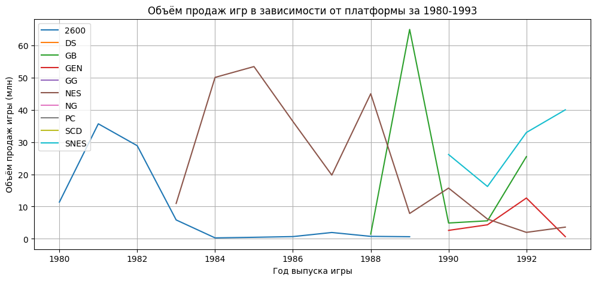

```python
#построение линейного графика продаж по платформам за 1980-1993
fig, ax = plt.subplots(figsize=(12, 5))
ax.set_title("Объём продаж игр в зависимости от платформы за 1980-1993")
ax.plot(games.query('year_of_release >= 1980 and year_of_release <= 1993')\
    .pivot_table(index='year_of_release', values='sales_sum', columns = 'platform', aggfunc = 'sum'))

ax.set_xlabel("Год выпуска игры")
ax.set_ylabel("Объём продаж игры (млн)")
ax.grid()
ax.legend(games.query('year_of_release >= 1980 and year_of_release <= 1993')\
    .pivot_table(index='year_of_release', values='sales_sum', columns = 'platform', aggfunc = 'sum'))
```

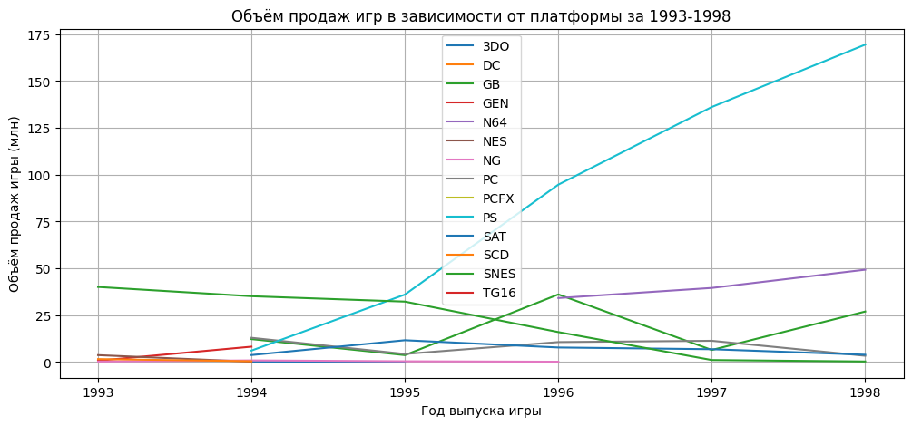

```python
#построение линейного графика продаж по платформам за 1993-1998
fig, ax = plt.subplots(figsize=(12, 5))
ax.set_title("Объём продаж игр в зависимости от платформы за 1993-1998")
ax.plot(games.query('year_of_release >= 1993 and year_of_release <= 1998')\
    .pivot_table(index='year_of_release', values='sales_sum', columns = 'platform', aggfunc = 'sum'))

ax.set_xlabel("Год выпуска игры")
ax.set_ylabel("Объём продаж игры (млн)")
ax.grid()
ax.legend(games.query('year_of_release >= 1993 and year_of_release <= 1998')\
    .pivot_table(index='year_of_release', values='sales_sum', columns = 'platform', aggfunc = 'sum'))
```

В период с 1993 по 1998 лидирует приставка PlayStation1 от Sony. При этом суммарные продажи в целом возрасли почти в три раза по сравнению с 1980-1993.

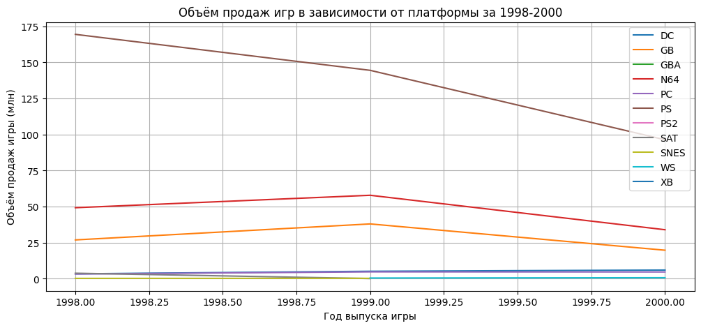

```python
#построение линейного графика продаж по платформам за 1998-2000
fig, ax = plt.subplots(figsize=(12, 5))
ax.set_title("Объём продаж игр в зависимости от платформы за 1998-2000")

ax.plot(games.query('year_of_release >= 1998 and year_of_release <= 2000')
.pivot_table(index='year_of_release', values='sales_sum', columns = 'platform', aggfunc = 'sum'))

ax.set_xlabel("Год выпуска игры")
ax.set_ylabel("Объём продаж игры (млн)")
ax.grid()
ax.legend(games.query('year_of_release >= 1998 and year_of_release <= 2000')
.pivot_table(index='year_of_release', values='sales_sum', columns = 'platform', aggfunc = 'sum'))
```

В период стагнации с 1998 по 2000 продолжает лидировать PS1.

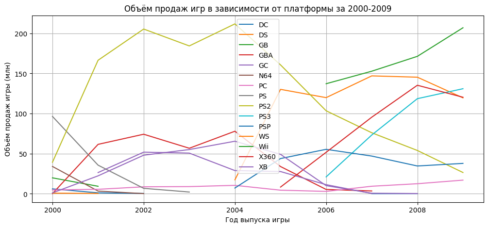

```python
#построение линейного графика продаж по платформам за 2000-2009
fig, ax = plt.subplots(figsize=(12, 5))
ax.set_title("Объём продаж игр в зависимости от платформы за 2000-2009")

ax.plot(games.query('year_of_release >= 2000 and year_of_release <= 2009')
    .pivot_table(index='year_of_release', values='sales_sum', columns = 'platform', aggfunc = 'sum'))

ax.set_xlabel("Год выпуска игры")
ax.set_ylabel("Объём продаж игры (млн)")
ax.grid()
ax.legend(games.query('year_of_release >= 2000 and year_of_release <= 2009')
    .pivot_table(index='year_of_release', values='sales_sum', columns = 'platform', aggfunc = 'sum'))
```

С 2000 по 2009 лидирует уже второе поколение PlayStation. К концу периода его обгоняет Wii от Nintendo. При этом PS2 и Wii повышают планку суммарных продаж.

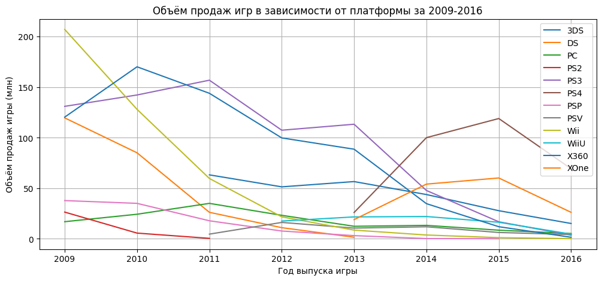

```python
#построение линейного графика продаж по платформам за 2009-2016
fig, ax = plt.subplots(figsize=(12, 5))
ax.set_title("Объём продаж игр в зависимости от платформы за 2009-2016")

ax.plot(games.query('year_of_release >= 2009 and year_of_release <= 2016')
    .pivot_table(index='year_of_release', values='sales_sum', columns = 'platform', aggfunc = 'sum'))

ax.set_xlabel("Год выпуска игры")
ax.set_ylabel("Объём продаж игры (млн)")
ax.grid()
ax.legend(games.query('year_of_release >= 2009 and year_of_release <= 2016')
    .pivot_table(index='year_of_release', values='sales_sum', columns = 'platform', aggfunc = 'sum'))
```

В период с 2009 по 2016 лидерами являются сначала X360 — консоль от Microsoft, затем домашние приставки PS3 и PS4 от Sony.

#### Изучение объёма продаж по самым успешным в разные периоды платформам

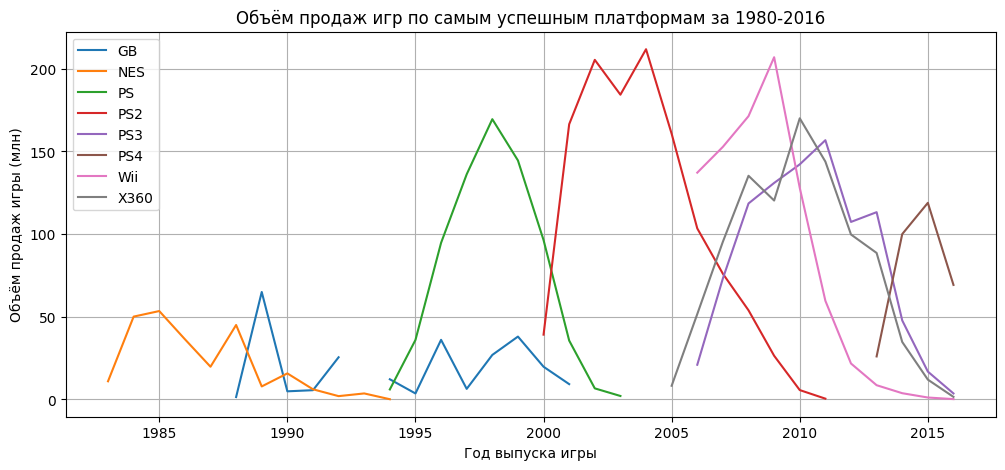

```python
#построение линейного графика продаж по самым успешным платформам за 1980-2016
fig, ax = plt.subplots(figsize=(12, 5))
ax.set_title("Объём продаж игр по самым успешным платформам за 1980-2016")

ax.plot(games.query('platform == "GB" or platform == "NES" or platform == "PS" or platform == "PS2" or platform == "Wii" or platform == "X360" or platform == "PS3" or platform == "PS4"')
    .pivot_table(index='year_of_release', values='sales_sum', columns = 'platform', aggfunc = 'sum'))

ax.set_xlabel("Год выпуска игры")
ax.set_ylabel("Объём продаж игры (млн)")
ax.grid()
ax.legend(games.query('platform == "GB" or platform == "NES" or platform == "PS" or platform == "PS2" or platform == "Wii" or platform == "X360" or platform == "PS3" or platform == "PS4"')
    .pivot_table(index='year_of_release', values='sales_sum', columns = 'platform', aggfunc = 'sum'))
```

#### Обоснование выбора периода с 2011 по 2016 года как актуального

По последнему графику видно, что в среднем платформы «живут» **10 лет**. У многих платформ график близок к форме «колокола». Пик продаж приходится на 4-5 год после выхода платформы.

В таком случае за **актуальный** период лучше всего взять последние 5 лет — период с 2011 по 2016 годы. За это время можно увидеть, какие платформы только начали набирать обороты, и предположить, сколько ещё лет они будут приносить прибыль, а какие уже теряют свои позиции.

### Выбор наиболее популярных платформ (2011-2016)

#### Формирование среза данных на основе актуального периода анализа

```python
#создание актуальной выборки, включающей записи с 2011 по 2016 годы
games_actual = games.query('year_of_release >= 2011 and year_of_release <= 2016')
```

```python
#вывод информации по созданному датасету
games_actual.info()
```

```
<class 'pandas.core.frame.DataFrame'>
Int64Index: 4021 entries, 16 to 16710
Data columns (total 12 columns):
 #   Column           Non-Null Count  Dtype
---  ------           --------------  -----
 0   name             4021 non-null   object
 1   platform         4021 non-null   object
 2   year_of_release  4021 non-null   float64
 3   genre            4021 non-null   object
 4   na_sales         4021 non-null   float64
 5   eu_sales         4021 non-null   float64
 6   jp_sales         4021 non-null   float64
 7   other_sales      4021 non-null   float64
 8   critic_score     4021 non-null   int64
 9   user_score       4021 non-null   float64
 10  rating           4021 non-null   object
 11  sales_sum        4021 non-null   float64
dtypes: float64(7), int64(1), object(4)
memory usage: 408.4+ KB
```

#### Изучение объёма продаж за периоды 2011-2016 и 2015-2016

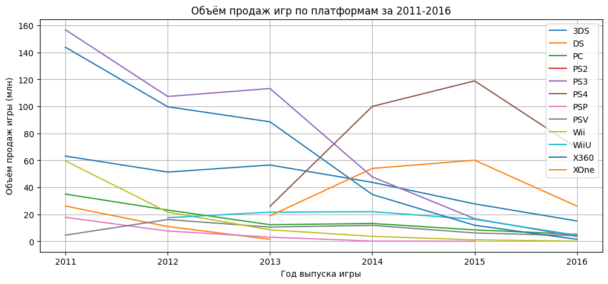

```python
#построение линейного графика продаж по платформам за 2011-2016
fig, ax = plt.subplots(figsize=(12, 5))
ax.set_title("Объём продаж игр по платформам за 2011-2016")

ax.plot(games.query('year_of_release >= 2011 and year_of_release <= 2016')
    .pivot_table(index='year_of_release', values='sales_sum', columns = 'platform', aggfunc = 'sum'))

ax.set_xlabel("Год выпуска игры")
ax.set_ylabel("Объём продаж игры (млн)")
ax.grid()
ax.legend(games.query('year_of_release >= 2011 and year_of_release <= 2016')
    .pivot_table(index='year_of_release', values='sales_sum', columns = 'platform', aggfunc = 'sum'))
```

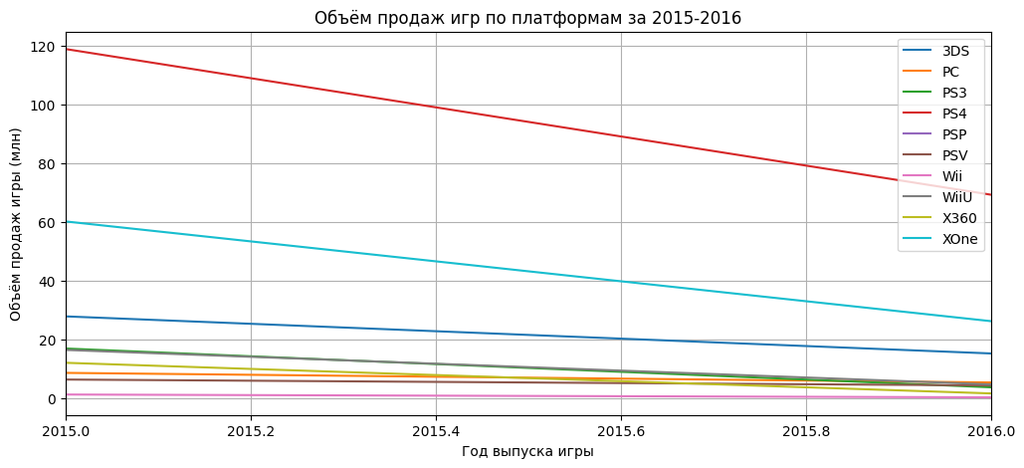

```python
#построение линейного графика продаж по платформам за 2015-2016, чтобы увидеть более точно,
#что происходит в эти последние два года
fig, ax = plt.subplots(figsize=(12, 5))
ax.set_title("Объём продаж игр по платформам за 2015-2016")

ax.plot(games.query('year_of_release >= 2015 and year_of_release <= 2016')
    .pivot_table(index='year_of_release', values='sales_sum', columns = 'platform', aggfunc = 'sum'))

ax.set_xlabel("Год выпуска игры")
ax.set_ylabel("Объём продаж игры (млн)")
ax.set_xlim(2015, 2016)
ax.grid()
ax.legend(games.query('year_of_release >= 2015 and year_of_release <= 2016')
    .pivot_table(index='year_of_release', values='sales_sum', columns = 'platform', aggfunc = 'sum'))
```

По продажам в выбранный период набирают обороты платформы PS4 и XOne. Теряют свои позиции — PS3 и 3DS.

#### Обоснование выбора PS4 и XboxOne в качестве потенциально прибыльных платформ

1. PS4 была запущена только в 2013-м году и, не смотря на убыль с 2015 года, будет держать планку ещё 2-3 года до выхода следующего поколения PlayStation — судя по графикам, PS меняются раз в 5-6 лет.
2. XboxOne была также запущена в 2013-м году. Период жизни продуктов Microsoft больше: например, X360 продержалась на высоких позициях с 2005 по 2013. Можно предположить, что XboxOne сможет удерживать свои позиции ещё 5 лет.

### Анализ наиболее популярных платформ: PS4 и XOne

#### Формирование среза данных на основе двух наиболее популярных платформ

```python
#выборка по двум самым популярным платформам
games_actual_most_pop = games_actual.query('platform == "PS4" or platform == "XOne"')
```

```python
#информация по выборке
games_actual_most_pop.info()
```

```
<class 'pandas.core.frame.DataFrame'>
Int64Index: 639 entries, 31 to 16668
Data columns (total 12 columns):
 #   Column           Non-Null Count  Dtype
---  ------           --------------  -----
 0   name             639 non-null    object
 1   platform         639 non-null    object
 2   year_of_release  639 non-null    float64
 3   genre            639 non-null    object
 4   na_sales         639 non-null    float64
 5   eu_sales         639 non-null    float64
 6   jp_sales         639 non-null    float64
 7   other_sales      639 non-null    float64
 8   critic_score     639 non-null    int64
 9   user_score       639 non-null    float64
 10  rating           639 non-null    object
 11  sales_sum        639 non-null    float64
dtypes: float64(7), int64(1), object(4)
memory usage: 64.9+ KB
```

Выборка из 639 наименований.

#### Анализ распределения объёма продаж по двум популярным платформам

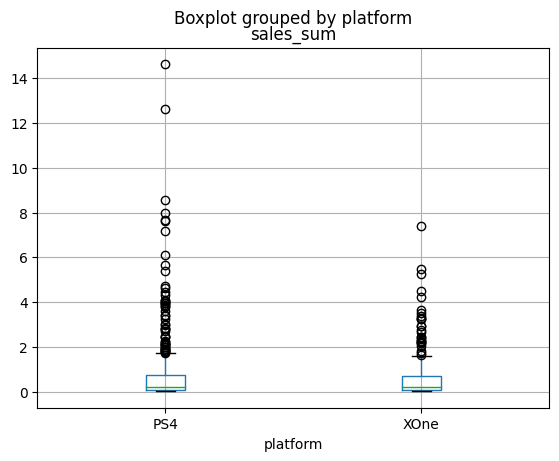

```python
#построение ящиков с усами для сравнения PS4 и XOne
games_actual_most_pop.boxplot(by = 'platform', column = 'sales_sum')
```

Видно, что на значения PS4 влияет много выбросов. Какие-то из игр продаются в количестве, которое не типично для PS4 — например, в количестве более 12 миллионов копий. А для XOne нетипичны значения выше 4 миллионов копий.

```
(-2.0, 4.0)
```

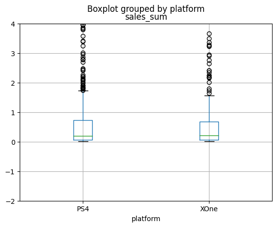

```python
#отображения ящиков с усами без сильных выбросов
games_actual_most_pop.boxplot(by = 'platform', column = 'sales_sum')
plt.ylim(-2, 4)
```

#### Анализ распределения объёма продаж по всем платформам, входящим в актуальный период

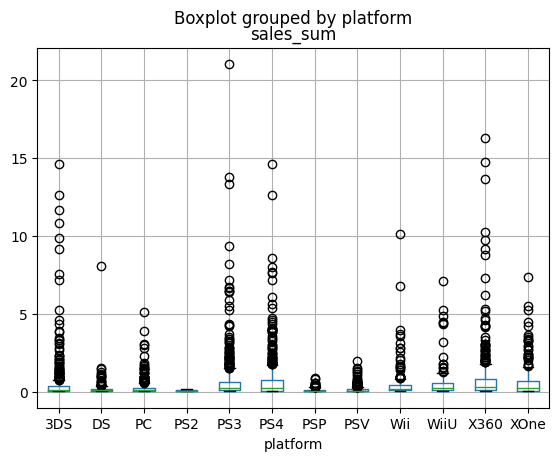

```python
#для понимания всей картины построим ящики для всех платформ за актуальный период
games_actual.boxplot(by = 'platform', column = 'sales_sum')
#plt.ylim(-2, 4)
```

```
(-2.0, 4.0)
```

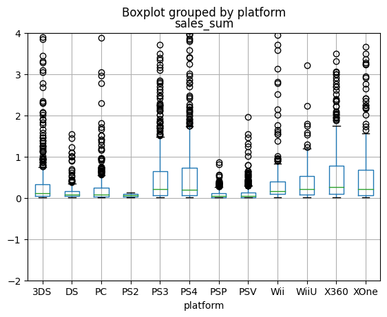

```python
#отображение ящиков с усами без сильных выбросов
games_actual.boxplot(by = 'platform', column = 'sales_sum')
plt.ylim(-2, 4)
```

Выходит, что у семейств домашних консолей PlayStation и Xbox стабильно высокие продажи. Наибольшее медианное значение объёма у X360.

#### Анализ влияния отзывов критиков и игроков на продажи игр PS4

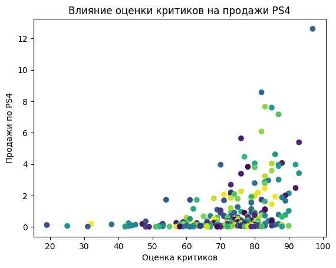

```python
#проверка того, как на продажи внутри PS4 влияют отзывы критиков
N = 252
colors = np.random.rand(N)
plt.scatter(x = games_actual_most_pop.query('platform == "PS4" and critic_score != 0')['critic_score'],
            y = games_actual_most_pop.query('platform == "PS4" and critic_score != 0')['sales_sum'], c=colors)


plt.title("Влияние оценки критиков на продажи PS4")
plt.xlabel("Оценка критиков")
plt.ylabel("Продажи по PS4")
plt.show()
```

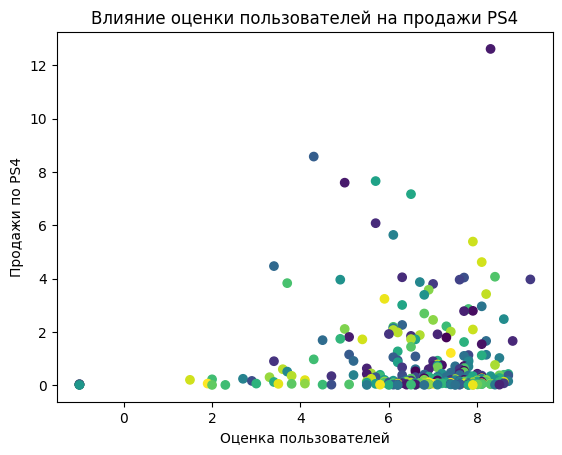

```python
#проверка того, как на продажи внутри PS4 влияют отзывы пользователей
N = 263
colors = np.random.rand(N)
plt.scatter(x = games_actual_most_pop.query('platform == "PS4" and user_score != 0')['user_score'],
            y = games_actual_most_pop.query('platform == "PS4" and user_score != 0')['sales_sum'], c=colors)


plt.title("Влияние оценки пользователей на продажи PS4")
plt.xlabel("Оценка пользователей")
plt.ylabel("Продажи по PS4")
plt.show()
```

```python
#вывод корреляционной матрицы для проверки влияния отзывов пользователей и критиков на продажи PS4
display(games_actual_most_pop.query('platform == "PS4" and critic_score != 0 and user_score != 0')[['sales_sum', 'critic_score', 'user_score']].corr())
```

|  | sales_sum | critic_score | user_score |
| --- | --- | --- | --- |
| sales_sum | 1.00 | 0.41 | -0.01 |
| critic_score | 0.41 | 1.00 | 0.51 |
| user_score | -0.01 | 0.51 | 1.00 |

#### Анализ влияния отзывов критиков и игроков на продажи игр XOne

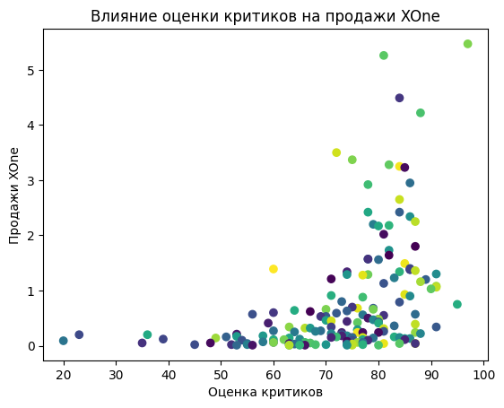

```python
#проверка того, как на продажи внутри XOne влияют отзывы критиков
N = 169
colors = np.random.rand(N)
plt.scatter(x = games_actual_most_pop.query('platform == "XOne" and critic_score != 0')['critic_score'],
            y = games_actual_most_pop.query('platform == "XOne" and critic_score != 0')['sales_sum'], c=colors)

plt.title("Влияние оценки критиков на продажи XOne")
plt.xlabel("Оценка критиков")
plt.ylabel("Продажи XOne")
plt.show()
```

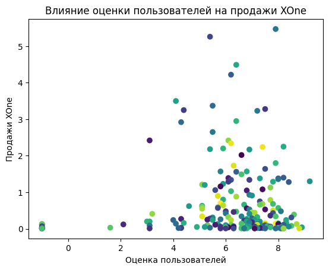

```python
#проверка того, как на продажи внутри XOne влияют отзывы пользователей
N = 193
colors = np.random.rand(N)
plt.scatter(x = games_actual_most_pop.query('platform == "XOne" and user_score != 0')['user_score'],
            y = games_actual_most_pop.query('platform == "XOne" and user_score != 0')['sales_sum'], c=colors)

plt.title("Влияние оценки пользователей на продажи XOne")
plt.xlabel("Оценка пользователей")
plt.ylabel("Продажи XOne")
plt.show()
```

```python
#вывод корреляционной матрицы для проверки влияния отзывов пользователей и критиков на продажи XOne
display(games_actual_most_pop.query('platform == "XOne" and critic_score != 0 and user_score != 0 and user_score != -1')[['sales_sum', 'critic_score', 'user_score']].corr())
```

|  | sales_sum | critic_score | user_score |
| --- | --- | --- | --- |
| sales_sum | 1.00 | 0.41 | -0.09 |
| critic_score | 0.41 | 1.00 | 0.47 |
| user_score | -0.09 | 0.47 | 1.00 |

**Выводы по диаграммам рассеяния и корреляционным матрицам:**

1. Высокие оценки критиков оказывают ощутимое положительное влияние на продажи — именно критики первыми оценивают игры и, как правило, до их выхода на продажу.
2. Влияние оценок пользователей имеет отрицательное влияние на продажи, но несущественное.
3. Статистики по платформам PS4 и XOne особо не отличаются.

#### Анализ влияния отзывов критиков и игроков на продажи игр других платформ (PC, 3DS, PSV, Wii)

Рассмотрим продажи на других платформах. Для примера возьмём **PC** и портативную консоль **3DS**. У них небольшие продажи и они представляют две другие категории игровых устройств.

```python
#вывод корреляционной матрицы для проверки влияния отзывов пользователей и критиков на продажи игр на PC
display(games_actual.query('platform == "PC" and critic_score != 0 and user_score != 0 and user_score != -1')[['sales_sum', 'critic_score', 'user_score']].corr())
```

|  | sales_sum | critic_score | user_score |
| --- | --- | --- | --- |
| sales_sum | 1.00 | 0.31 | -0.06 |
| critic_score | 0.31 | 1.00 | 0.46 |
| user_score | -0.06 | 0.46 | 1.00 |

```python
#вывод корреляционной матрицы для проверки влияния отзывов пользователей и критиков на продажи игр на 3DS
display(games_actual.query('platform == "3DS" and critic_score != 0 and user_score != 0 and user_score != -1')[['sales_sum', 'critic_score', 'user_score']].corr())
```

|  | sales_sum | critic_score | user_score |
| --- | --- | --- | --- |
| sales_sum | 1.00 | 0.34 | 0.23 |
| critic_score | 0.34 | 1.00 | 0.75 |
| user_score | 0.23 | 0.75 | 1.00 |

Рассмотрим дополнительно корреляцию по **PSV**. Вдруг для портативных консолей характерно влияние пользовательских оценок на продажи.

```python
#вывод корреляционной матрицы для проверки влияния отзывов пользователей и критиков на продажи игр на PSV
display(games_actual.query('platform == "PSV" and critic_score != 0 and user_score != 0 and user_score != -1')[['sales_sum', 'critic_score', 'user_score']].corr())
```

|  | sales_sum | critic_score | user_score |
| --- | --- | --- | --- |
| sales_sum | 1.00 | 0.13 | 0.04 |
| critic_score | 0.13 | 1.00 | 0.73 |
| user_score | 0.04 | 0.73 | 1.00 |

Возможно, что влияние оценки пользователей на продажи игр на платформах Nintendo связано с особенностями рынка Японии. Проверим корреляцию по **Wii**.

```python
#вывод корреляционной матрицы для проверки влияния отзывов пользователей и критиков на продажи игр на Wii
display(games_actual.query('platform == "Wii" and critic_score != 0 and user_score != 0 and user_score != -1')[['sales_sum', 'critic_score', 'user_score']].corr())
```

|  | sales_sum | critic_score | user_score |
| --- | --- | --- | --- |
| sales_sum | 1.00 | 0.25 | 0.15 |
| critic_score | 0.25 | 1.00 | 0.44 |
| user_score | 0.15 | 0.44 | 1.00 |

### Анализ продаж игр по жанрам

#### Динамика объёма продаж игр по жанрам за 2011-2016 гг.

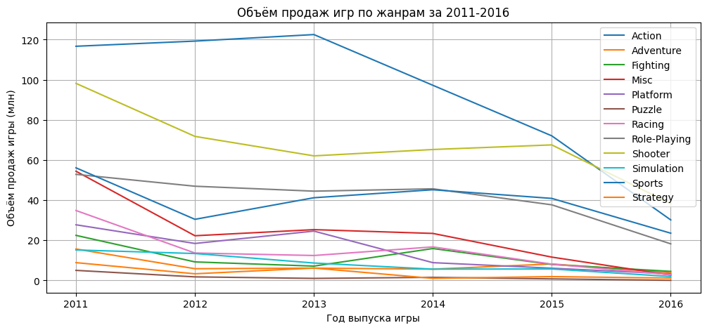

```python
#построение линейного графика продаж по жанрам за 2011-2016
fig, ax = plt.subplots(figsize=(12, 5))
ax.set_title("Объём продаж игр по жанрам за 2011-2016")

ax.plot(games_actual.pivot_table(index='year_of_release', values='sales_sum', columns = 'genre', aggfunc = 'sum'))

ax.set_xlabel("Год выпуска игры")
ax.set_ylabel("Объём продаж игры (млн)")
ax.grid()
ax.legend(games_actual.pivot_table(index='year_of_release', values='sales_sum', columns = 'genre', aggfunc = 'sum'))
```

#### Подсчёт доли каждого жанра в общем количестве релизов и объёме продаж

```python
#доля игр в каждом жанре
games_actual.groupby('genre')['name'].count().sort_values(ascending = False) / games_actual['name'].count() * 100
```

```
genre
Action         31.56
Role-Playing   11.56
Adventure      10.20
Sports          9.65
Misc            9.33
Shooter         8.18
Racing          4.48
Fighting        3.95
Simulation      3.38
Platform        3.03
Strategy        2.91
Puzzle          1.77
Name: name, dtype: float64
```

```python
#посчитаем медианные значения объёма продаж игр по жанрам
games_actual.groupby('genre')['sales_sum'].median().sort_values(ascending = False)
```

```
genre
Shooter        0.41
Sports         0.20
Platform       0.18
Fighting       0.18
Racing         0.16
Role-Playing   0.15
Action         0.13
Misc           0.13
Simulation     0.11
Strategy       0.08
Puzzle         0.05
Adventure      0.03
Name: sales_sum, dtype: float64
```

Больше всего игр выходит в жанре **Action**, но лучше всего продаются игры в жанре **Shooter**.

### Портрет пользователя каждого региона

#### Разница в жанровых предпочтениях

```python
#проверка данных по жанрам по Северной Америке
games_actual.groupby('genre')['na_sales'].sum().sort_values(ascending = False) / games_actual['na_sales'].sum() * 100
```

```
genre
Action         27.83
Shooter        23.43
Sports         13.10
Role-Playing   10.10
Misc            8.40
Platform        4.61
Racing          3.85
Fighting        3.81
Simulation      1.85
Adventure       1.78
Strategy        0.90
Puzzle          0.33
Name: na_sales, dtype: float64
```

```python
#проверка данных по ЕС
games_actual.groupby('genre')['eu_sales'].sum().sort_values(ascending = False) / games_actual['eu_sales'].sum() * 100
```

```
genre
Action         29.73
Shooter        22.10
Sports         13.21
Role-Playing    9.30
Racing          6.06
Misc            5.93
Platform        4.49
Simulation      2.94
Fighting        2.42
Adventure       2.08
Strategy        1.20
Puzzle          0.53
Name: eu_sales, dtype: float64
```

```python
#проверка данных по Японии
games_actual.groupby('genre')['jp_sales'].sum().sort_values(ascending = False) / games_actual['jp_sales'].sum() * 100
```

```
genre
Role-Playing   32.51
Action         25.90
Misc            7.16
Fighting        5.04
Platform        4.94
Adventure       4.91
Shooter         4.85
Simulation      4.74
Sports          4.51
Racing          2.30
Strategy        1.95
Puzzle          1.18
Name: jp_sales, dtype: float64
```

#### Разница в предпочтениях платформ

```python
#проверка данных по платформам по Северной Америке
games_actual.groupby('platform')['na_sales'].sum().sort_values(ascending = False) / games_actual['na_sales'].sum() * 100
```

```
platform
X360   27.33
PS3    20.28
PS4    13.10
XOne   11.22
3DS     9.96
Wii     5.85
WiiU    4.59
PC      3.60
DS      2.27
PSV     1.50
PSP     0.26
PS2     0.02
Name: na_sales, dtype: float64
```

```python
#проверка данных по платформам по ЕС
games_actual.groupby('platform')['eu_sales'].sum().sort_values(ascending = False) / games_actual['eu_sales'].sum() * 100
```

```
platform
PS3    24.35
PS4    21.07
X360   17.48
3DS     9.15
PC      8.47
XOne    7.70
Wii     4.42
WiiU    3.75
PSV     1.95
DS      1.38
PSP     0.26
PS2     0.02
Name: eu_sales, dtype: float64
```

```python
#проверка данных по платформам по Японии
games_actual.groupby('platform')['jp_sales'].sum().sort_values(ascending = False) / games_actual['jp_sales'].sum() * 100
```

```
platform
3DS    40.96
PS3    20.11
PSP     9.79
PSV     8.89
PS4     6.50
WiiU    5.30
Wii     3.65
DS      3.27
X360    1.36
XOne    0.14
PS2     0.04
PC      0.00
Name: jp_sales, dtype: float64
```

#### Влияние рейтинга ESRB на продажи по регионам

```python
#создание функции, возвращающей по отметке рейтинга ESRB начальный возраст
#RP — рейтинг ещё не назначен, поэтому unknown
def esrb_category (esrb):
    if esrb == 'EC':
        return 3
    elif esrb == 'E':
        return 0
    elif esrb == 'E10+':
        return 10
    elif esrb == 'T':
        return 13
    elif esrb == 'M':
        return 17
    elif esrb == 'AO':
        return 18
    elif esrb == 'unknown':
        return -1
    else:
        return "unknown"
```

```python
#создание колонки с начальными возрастами, соответствующими рейтингу ESRB
games_actual['esrb_category'] = games_actual.apply(lambda x: esrb_category(x['rating']), axis = 1)
```

```python
#создание выборки без строк, где рейтинг не указан
games_actual_esrb = games_actual[games_actual['esrb_category'] != 'unknown']
#изменение типа данных на целочисленный для значений рейтинга
games_actual_esrb['esrb_category'] = games_actual_esrb['esrb_category'].astype(int)
```

```python
#анализ суммарных продаж в Японии по рейтингу ESRB
games_actual_esrb.groupby('esrb_category')['jp_sales'].sum().sort_values(ascending = False) / games_actual_esrb['jp_sales'].sum() * 100
```

```
esrb_category
-1    56.26
 0    14.93
 13   13.59
 17   10.64
 10    4.57
 3     0.00
Name: jp_sales, dtype: float64
```

```python
#анализ суммарных продаж в Северной Америке по рейтингу ESRB
games_actual_esrb.groupby('esrb_category')['na_sales'].sum().sort_values(ascending = False) / games_actual_esrb['na_sales'].sum() * 100
```

```
esrb_category
 17   37.17
 0    20.51
-1    14.91
 10   14.19
 13   13.17
 3     0.05
Name: na_sales, dtype: float64
```

```python
#анализ суммарных продаж в ЕС по рейтингу ESRB
games_actual_esrb.groupby('esrb_category')['eu_sales'].sum().sort_values(ascending = False) / games_actual_esrb['eu_sales'].sum() * 100
```

```
esrb_category
 17   37.37
 0    21.16
-1    17.41
 13   12.42
 10   11.65
 3     0.00
Name: eu_sales, dtype: float64
```

**Выводы по портретам игроков в разных регионах**

**Примечание:** Misc — это игры, созданные на пересечении разных жанров.

**Выводы по платформам:**

В Северной Америки большую часть рынка занимают платформы X360 (27%), PS4 (13%), PS3 (20%). При этом лидирует X360. Тогда как в ЕС лидирует PS3 (24%) при том, что большую часть рынка так же делят PS4 (21%) и X360 (17%). В Японии наибольшей популярностью пользуется продукт от Nintendo — 3DS (40%), с ним рынок делит PS3, но его популярность в два раза меньше — всего 20%.

Низкая популярность PS4 связана с тем, что эта платформа появилась намного позже PS3, и для неё ещё не вышло так много игр, как есть на PS3. В целом, можно ориентироваться на домашние консоли от **Sony (PS)** — они популярны во всех трёх регионах.

**Влияние рейтинга ESRB:**

В Японии лучше всего продаются игры, где рейтинг ESRB не указан, но это и не удивительно, т.к. японцы потребляют больше игр от Nintendo, к которым североамериканский рейтинг и не применяется. В Северной Америке и ЕС большая доля продаж приходится на игры для аудитории 17+.

## Статистический анализ данных

### Проверка гипотезы о равенстве пользовательских рейтингов игр платформ XboxOne и PC

#### Проверка размера выборок

```python
#проверка количество значений в выборке по XOne
games_actual[games_actual['platform'] =='XOne'].shape
```

```
(247, 13)
```

```python
#проверка количество значений в выборке по PC
games_actual[games_actual['platform'] =='PC'].shape
```

```
(389, 13)
```

Можно делать **t-тест для двух генеральных совокупностей**:

1. Они независимы: средние не берутся из одной и той же генеральной совокупности до и после её изменения.
2. Выборочные средние, которые проверяются, нормально распределены. Согласно ЦПТ, если размер выборки составляет хотя бы несколько десятков значений, выборочные средние, которые можно получить из одной и той же генеральной совокупности, будут распределены нормально вокруг истинного среднего этой совокупности. Выборочные средние берутся из выборок, где n1 = 247, n2 = 389.

#### Формулирование и проверка статистических гипотез

```
H_0: Пользовательский рейтинг игр на платформе XboxOne = пользовательский рейтинг игр на платформе PC`
H_a: Пользовательский рейтинг игр на платформе XboxOne ≠ пользовательский рейтинг игр на платформе PC`
alpha = 0.05
```

```python
#проверка гипотезы, что средние пользовательские рейтинги игр, сделанных на платформах Xbox One и PC одинаковые
results = st.ttest_ind(games_actual[games_actual['platform'] =='XOne']['user_score'],
                      games_actual[games_actual['platform'] =='PC']['user_score'],
                      equal_var=False)
alpha = .05

print(results.pvalue)
# условный оператор с выводом строки с ответом
if results.pvalue < alpha:
    print('Отвергаем нулевую гипотезу')
else:
    print('Принимаем нулевую гипотезу')
```

```
0.2665651578280093
Принимаем нулевую гипотезу
```

Можно говорить, что гипотезу о равенстве двух выборок не удалось опровергнуть. Значит пользовательский рейтинг игр с большой вероятностью не зависит от платформы (PC или XboxOne).

### Проверка гипотезы о равенстве пользовательских рейтингов игр в жанрах Action и Sports

#### Проверка размера выборок

```python
#проверка количество значений в выборке по Action
games_actual[games_actual['genre'] =='Action'].shape
```

```
(1269, 13)
```

```python
#проверка количество значений в выборке по Sports
games_actual[games_actual['genre'] =='Sports'].shape
```

```
(388, 13)
```

Можно делать **t-тест для двух генеральных совокупностей**:

#### Формулирование и проверка статистических гипотез

```
H_0: Пользовательский рейтинг игр в жанре Action = пользовательский рейтинг игр в жанре Sports`
H_a: Пользовательский рейтинг игр в жанре Action ≠ пользовательский рейтинг игр в жанре Sports"`
alpha = 0.05
```

```python
#проверка гипотезы, что средние пользовательские рейтинги игр в жанре Action и Sports разные
results = st.ttest_ind(games_actual[games_actual['genre'] =='Action']['user_score'],
                      games_actual[games_actual['genre'] =='Sports']['user_score'],
                      equal_var=False)
alpha = .05

print(results.pvalue)
# условный оператор с выводом строки с ответом
if results.pvalue < alpha:
    print('Отвергаем нулевую гипотезу')
else:
    print('Принимаем нулевую гипотезу')
```

```
0.8372434995256783
Принимаем нулевую гипотезу
```

Можно говорить, что гипотезу о равенстве двух выборок не удалось опровергнуть — пользовательский рейтинг игр с большой вероятностью не зависит от самих жанров (Action и Sport).

## Общий вывод

**Краткое описание проделанной работы:**

1. Были посчитаны суммарные продажи по всем играм.
2. Было определено, что в среднем платформы «живут» 10 лет. Пик продаж обычно приходится на 4-5 год «жизни» платформы.
3. Был выбран наиболее актуальный период для оценки тенденций на рынке видеоигр — с 2011 по 2016.
4. Было определо, что платформы семейства PlayStation устаревают за 5 лет, тогда как платформы от Microsoft держатся на высоких позициях около 10 лет.
5. Было выяснено, что лучше всего продаются игры, которые выпускаются на платформах семейства Xbox и PlayStation. И у них же наиболее стабильно высокие продажи.
6. Было определено, что самыми прибыльными являются игры в жанре Action и Shooter, а самыми низкими продажами отличаются игры в жанре Puzzle.
7. Было также определено, что продажи Nintendo в большей степени зависят от отзывов пользователей, чем продажи игр на других платформах.

**Фокус в рекламной кампании онлайн-магазина по продаже игр должен быть сделан на играх**:

- выпущенных на PS3 и PS4 — это самые популярные платформы по всему миру;
- в жанре Action - во всех трёх регионах этот жанр занимает значительную долю продаж;
- в жанре Shooter — игры в этом жанре продаются лучше всего.